# Assignment 3 Solutions

**Problem 1** Problem 1 will recieve full credit for completion as long as the solution satisfied the instructions. The following are suggested ways to consider these problems, and some techniques that can help with data analysis.

```r
library(faraway)
library(ggplot2)
```

**Problem 1.1**

We will plot the relationship between weekly income and gambling expenditures, but separate out the values by the reported sex. To do this, we should convert the “sex” column into a factor vector with levels associated to the labels “Male” and “Female”, which are coded as integers in the data. We use the package “plyr” to use the function “revalue” for this purpose.

```r
library(plyr)
```

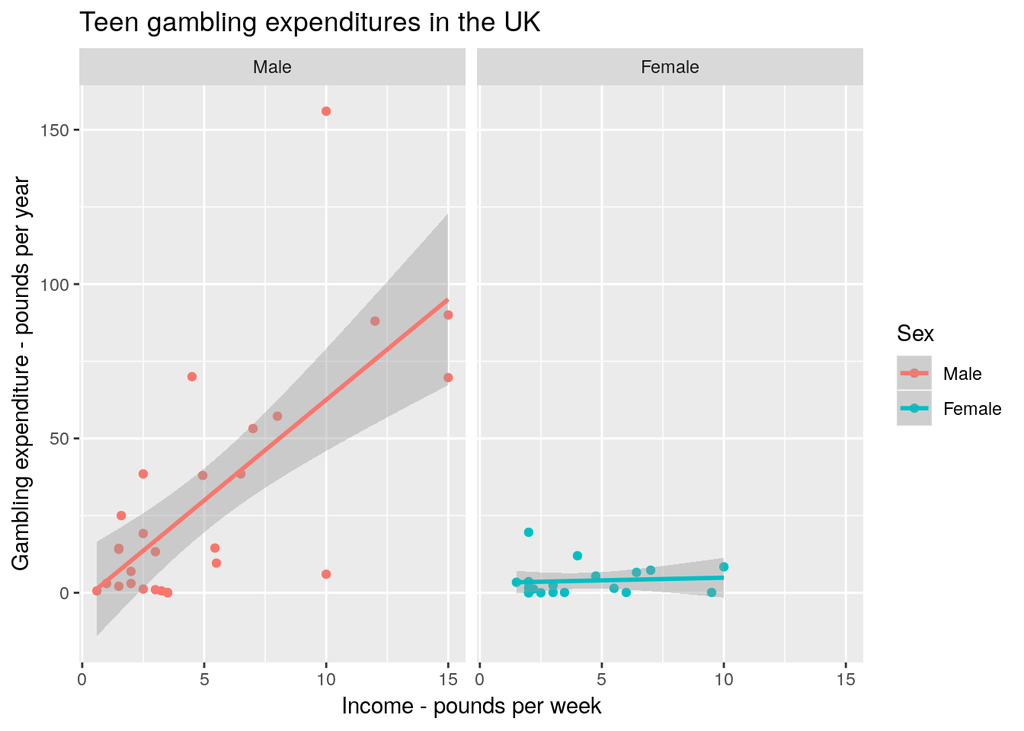

```r
tg_sex <- as.factor(teengamb$sex)
tg_sex <- revalue(tg_sex, c("0"="Male", "1"="Female"))
teengamb$sex <- tg_sex
ggplot(data=teengamb, aes(x=income, y=gamble, color=sex)) + geom_point() + geom_smooth(method='lm') + facet_wrap(~ sex) +
  labs(
    x="Income - pounds per week",
    y="Gambling expenditure - pounds per year",
    title="Teen gambling expenditures in the UK",
    color="Sex"
  )
```

We note that when we separate out the reported sex, there is a trend between increasing income and increasing gambling expenditures for men. However, for women the relationship between wages and gambling expenditure is basically flat.

**Problem 1.2**

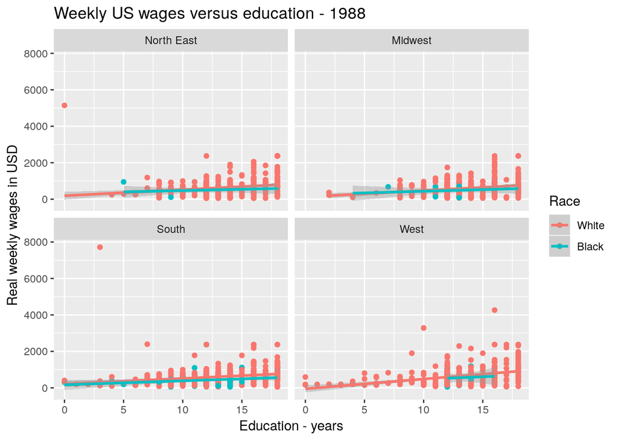

```r
usw_race <- as.factor(uswages$race)
usw_race<- revalue(usw_race, c("0"="White", "1"="Black"))
uswages$race <- usw_race
region <- uswages$ne + uswages$mw*2 + uswages$so*3 + uswages$we*4
region <- as.factor(region)
region <- revalue(region, c("1"="North East", "2"="Midwest", "3"="South", "4"="West"))
uswages$region <- region
ggplot(data=uswages, aes(x=educ, y=wage, color=race)) + geom_point() + geom_smooth(method='lm') + facet_wrap(~ region) +
  labs(
    x="Education - years",
    y="Real weekly wages in USD",
    title="Weekly US wages versus education - 1988",
    color="Race"
  )
```

Firstly we see that for individuals reported as “White”, there is a slight trend between increasing education and increasing income. This isn’t uniformly the case, and this trend is expressed in part with an increasing range of income values with years of eduction. However, for individuals reported as “Black”, the trend between years of education and income is largely flat with a much smaller range of values for income in general. We note that regionally, there ins’t significant variation in the trends aside from the differences in reported years of education.

**Problem 1.3**

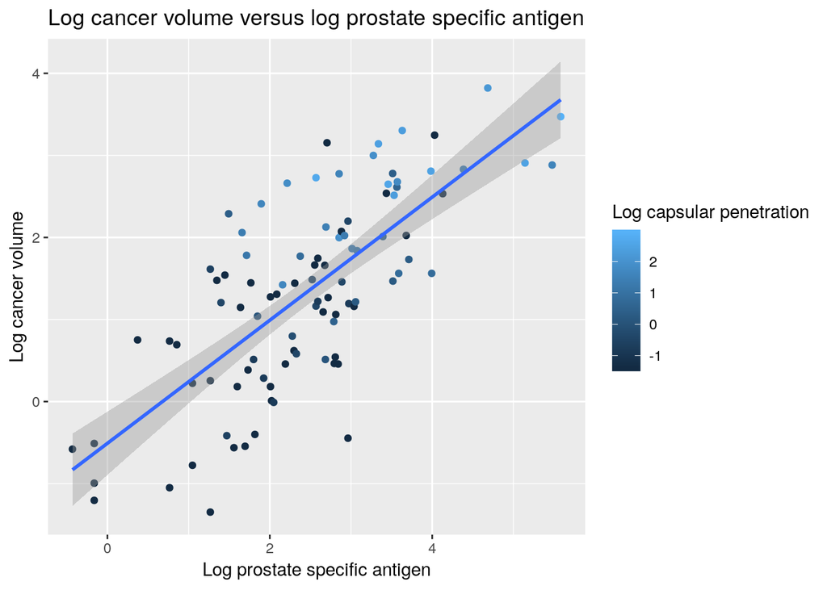

```r
ggplot(data=prostate, aes(x=lpsa, y=lcavol, color=lcp)) + geom_point() + geom_smooth(method='lm') +
  labs(
    x="Log prostate specific antigen",
    y="Log cancer volume",
    title="Log cancer volume versus log prostate specific antigen",
    color="Log capsular penetration"
  )
```

We find a strong trend that when the prostate specific antigent (lpsa) increases so does the log cancer volume. It appears that the log capsular penetration has a similar increasing trend with increasing lpsa.

**Problem 1.4**

By investigating the data enough, we may notice that there is multi-modality in the total test scores with a block of relatively high and relatively low total scores. We will separate the data into two groups based on whether they are equal and above the median or below the median.

```r
summary(sat$total)
```

```
##    Min. 1st Qu.  Median    Mean 3rd Qu.    Max.
##   844.0   897.2   945.5   965.9  1032.0  1107.0
```

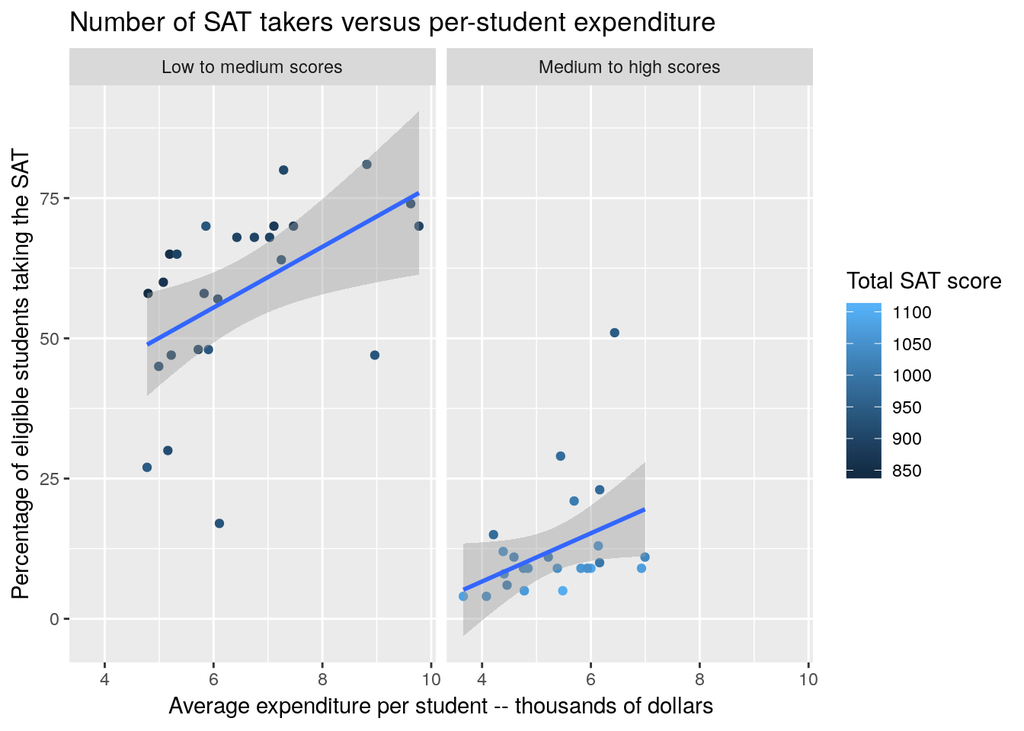

```r
hi_lo <- sat$total
hi_lo <- as.factor(hi_lo >=945.5)
hi_lo <- revalue(hi_lo, c("FALSE"="Low to medium scores", "TRUE"="Medium to high scores"))
sat$hi_lo <- hi_lo
ggplot(data=sat, aes(x=expend, y=takers, color=total)) + geom_point() + geom_smooth(method='lm') +
  facet_wrap(~hi_lo) +
  labs(
    x="Average expenditure per student -- thousands of dollars",
    y="Percentage of eligible students taking the SAT",
    title="Number of SAT takers versus per-student expenditure",
    color="Total SAT score"
  )
```

We note that separating the data into the upper and lower 50 percentile, we see that there is a consistent pattern where the percentage of eligible students taking the SAT increases with the average expenditure per student. Interestingly, the schools with the upper 50 percentile average on the SAT also largely have a significantly lower percentage of eligible students taking the SAT. In order to evaluate the impact of avearge expenditures per student, the data should be understood in terms of the large discepancy in the number of eligible students taking the exams between the two modes in the data.

**Problem 1.5**

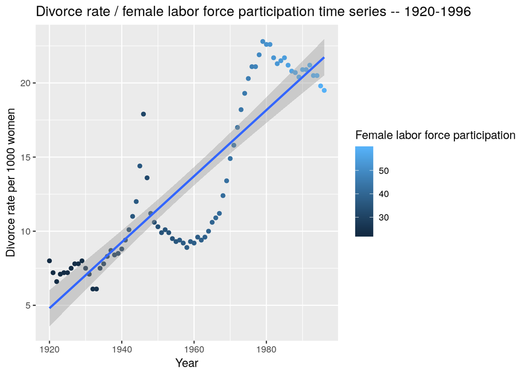

```r
ggplot(data=divusa, aes(x=year, y=divorce, color=femlab)) + geom_point() + geom_smooth(method='lm') +
  labs(
    x="Year",
    y="Divorce rate per 1000 women",
    title="Divorce rate / female labor force participation time series -- 1920-1996",
    color="Female labor force participation"
  )
```

We note that there is a trend over time of both higher divorce rates and female labor force participation. The trend in each case appears with some variation. Particularly, the divorce rate also appears to correlate strongly with several significant historical events in the USA: (i) the Great Depression; (ii) World War 2; (iii) the Baby Boom; (iv) 1960’s and 1970’s cultural movements.

**Problem 2.1** Note the following,

$$\begin{align}
\mathbf{H} &= \mathbf{X}\left(\mathbf{X}^\mathrm{T}\mathbf{X}\right)^{-1} \mathbf{X}^\mathrm{T}
\end{align}$$
such that,
$$\begin{align}
\mathbf{H}^2 &= \mathbf{X}\left(\mathbf{X}^\mathrm{T}\mathbf{X}\right)^{-1} \mathbf{X}^\mathrm{T}\mathbf{X}\left(\mathbf{X}^\mathrm{T}\mathbf{X}\right)^{-1} \mathbf{X}^\mathrm{T} \\
&= \mathbf{X}\left(\mathbf{X}^\mathrm{T}\mathbf{X}\right)^{-1} \left(\mathbf{X}^\mathrm{T}\mathbf{X}\right)\left(\mathbf{X}^\mathrm{T}\mathbf{X}\right)^{-1} \mathbf{X}^\mathrm{T}\\
&= \mathbf{X}\mathbf{I}\left(\mathbf{X}^\mathrm{T}\mathbf{X}\right)^{-1} \mathbf{X}^\mathrm{T}\\
& =\mathbf{H}
\end{align}$$

**Problem 2.2** Note that,
$$\begin{align}
(\mathbf{I} - \mathbf{H})^2 &= \mathbf{I} - \mathbf{H} - \mathbf{H} + \mathbf{H}^2
\end{align}$$
and by problem 2.1, we know that
$$\begin{align}
(\mathbf{I} - \mathbf{H})^2 &= \mathbf{I} - \mathbf{H} - \mathbf{H} + \mathbf{H}\\
& = \mathbf{I}- \mathbf{H}
\end{align}$$